# Week 3: HW - Visualizing Air Quality Analysis

Victor Arencibia

1/29/2022

# Instructions

Use the built-in `airquality` R dataset to visualize the air quality in 1973. Explore the patterns in the data by creating histograms, boxplots, line graphs, heatmaps, and scatterplots.

Load the libraries `ggplot2` and `reshape2` in the setup chunk below.

```r
# Add your library below.
EnsurePackage <- function(x) {
x <- as.character(x)
if (!require(x,character.only=TRUE)) {
  install.packages(pkgs=x, repos="https://cran.r-project.org")
  require(x,character.only=TRUE)
  }
}
EnsurePackage("ggplot2")
EnsurePackage("reshape2")
library(Hmisc)
library(dplyr)
EnsurePackage("dplyr")
library(tidyr)
library(ggplot2)
```

# Step 1 - Load the Data

We will use the `airquality` dataset that you have as part of your R installation. Read the `airquality` data using the `data.frame()` function and save it as `air`.

```r
# Write your code below.
data("airquality")
```

# Step 2 - Clean the Data

After you load the data, there will be some NA values in the data. You need to figure out what to do about those nasty NAs. Google is your friend. Use Google actively to find a way to get rid of NAs using R.

**HINT:** Find columns that include NA values first (use `colSums()` function, then replace NAs with the mean value of these columns).

Optional: If you want to implement a better approaches to deal with missing data, “multiple imputation” would be where you should go.  
You can check sources like:

- https://gking.harvard.edu/amelia
- http://cran.revolutionanalytics.com/web/packages/mitools/index.html

```r
# Write your code below.

airdata <- na.omit(airquality)
colSums(is.na(airdata))
```

```
##   Ozone Solar.R    Wind    Temp   Month     Day
##       0       0       0       0       0       0
```

# Step 3 - Understand the data distribution

Create the following visualizations:

- Histograms for each of the variables
- Boxplot for `Ozone`, and boxplots for different `wind` values (round `wind` to get a good number of “buckets”)

**HINT:** you can create one graph with `Ozone` as X-axis and `Wind` as Y-axis. Also, you can create two graphs (one with `Ozone` values on the Y-axis, and another one with Y-axis value is rounded value of `Wind`). In this case, you need to create a fake grouping variable `(x = factor(0))`.

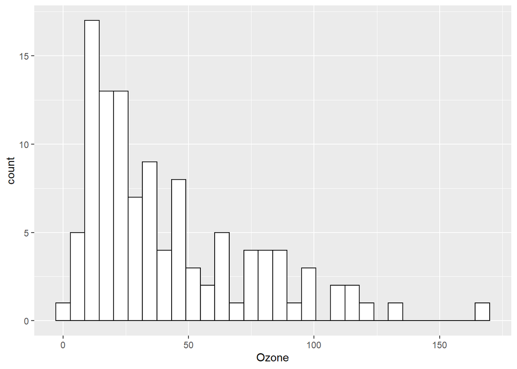

```r
# Write your code below.

#hist.data.frame(air)
airdata <- airdata %>%
 mutate_if(is.numeric, round)
#air$Ozone <- as.factor(air$Ozone)
#air$Wind <- as.factor(air$Wind)
#ggplot(air, aes(factor(0), y = Ozone)) + geom_boxplot(group = 1)
#ggplot(air, aes(factor(0), y = Wind)) + geom_boxplot()

ggplot(airdata,aes(x=Ozone)) + geom_histogram(color = "black", fill = "white")
```

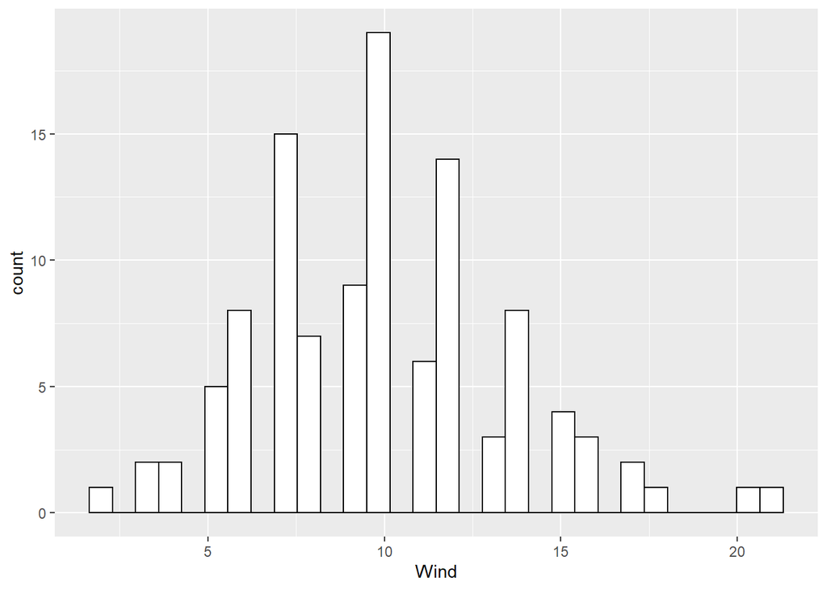

```r
ggplot(airdata,aes(x=Wind)) + geom_histogram(color = "black", fill = "white")
```

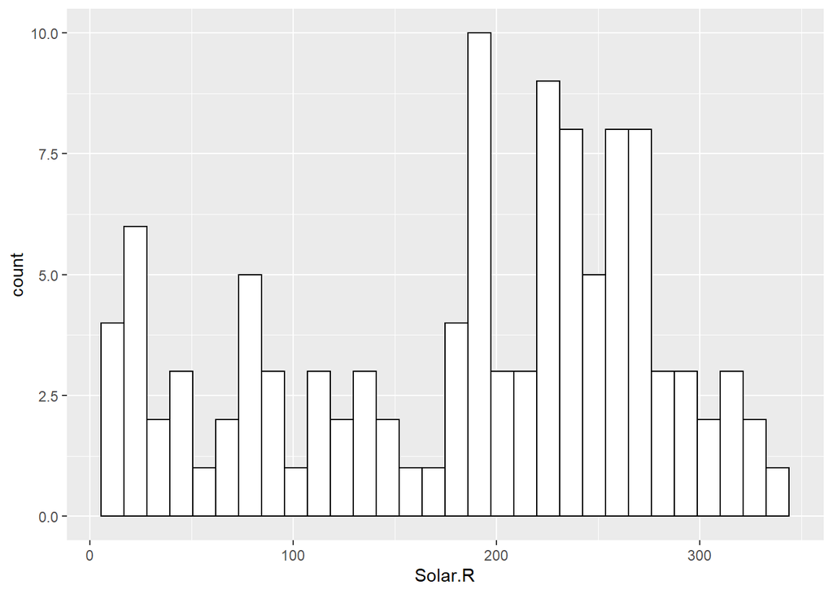

```r
ggplot(airdata,aes(x=Solar.R)) + geom_histogram(color = "black", fill = "white")
```

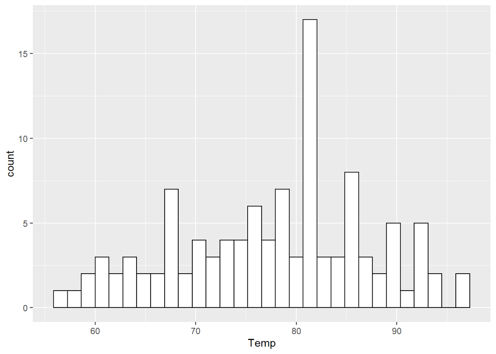

```r
ggplot(airdata,aes(x=Temp)) + geom_histogram(color = "black", fill = "white")
```

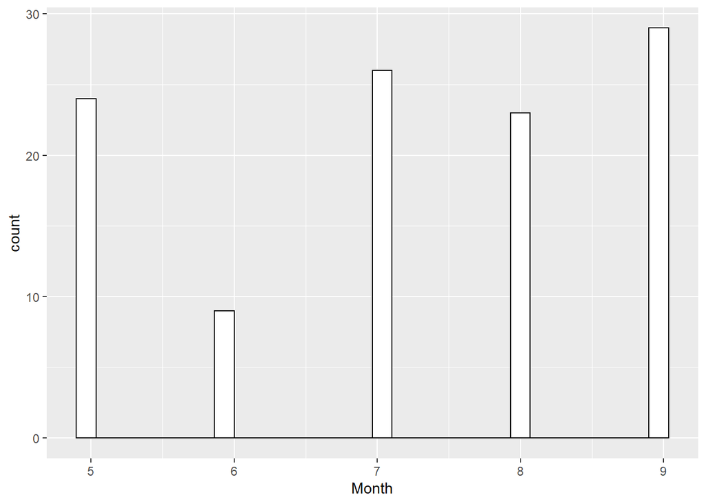

```r
ggplot(airdata,aes(x=Month)) + geom_histogram(color = "black", fill = "white")
```

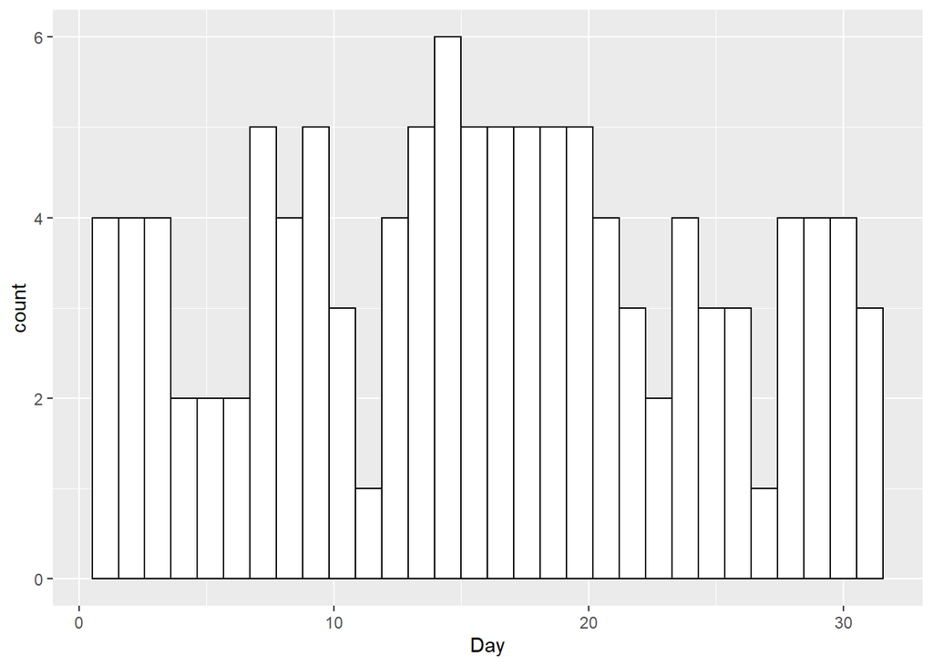

```r
ggplot(airdata,aes(x=Day)) + geom_histogram(color = "black", fill = "white")
```

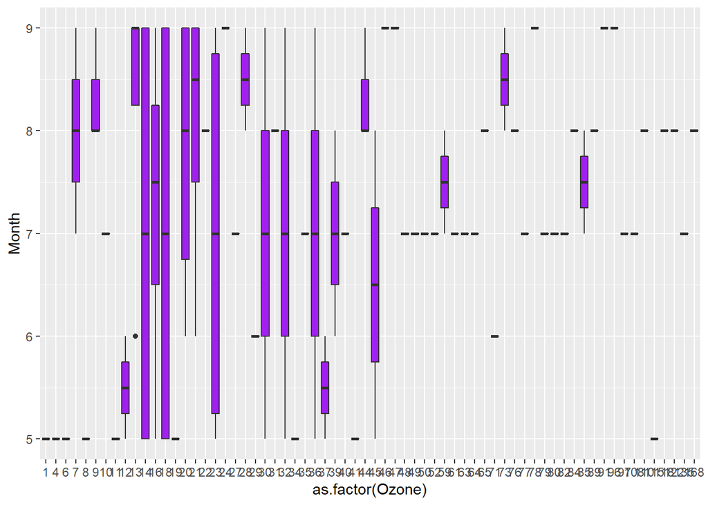

```r
ggplot(airdata,aes(as.factor(Ozone),Month)) + geom_boxplot(fill = 'purple')
```

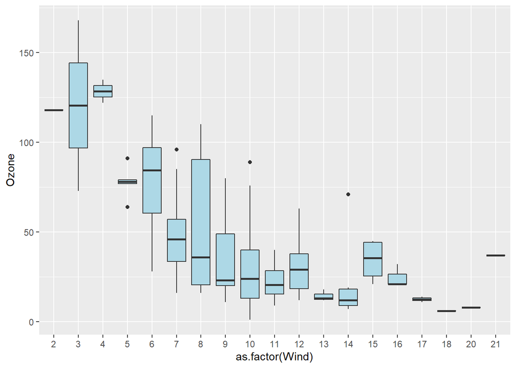

```r
ggplot(airdata,aes(as.factor(Wind),Ozone)) + geom_boxplot(fill = 'lightblue')
```

# Step 4 - Explore how the data changes over time

First, create the appropriate dates (this data was from 1973). Then create line charts for `Ozone`, `Temp`, `Wind` and `Solar.R` (one line chart for each, and then one chart with 4 lines, each variable having a different color).

**HINT:**

1. Combine (use `paste()` function) 1973 with the `Month` and `Day` columns, using “/” in between
2. Use `as.Date()` function to transform the value to “Date” format and create a `Date` column to record this value. Use `?as.Date` to find example use of this function.

Note that for the chart with 4 lines, you need to think about how to effectively use the y-axis.

**HINT:** You need to “melt” the columns so that it becomes “long” format. You can either use the `melt()` function or use the `gather()` from the “tidyr” package for the process. Also, compared to other values, the `Wind` values are too small, so they are close to the x-axis. You need to multiply `Wind` by 10 to address this problem.

The correct result should look like this:

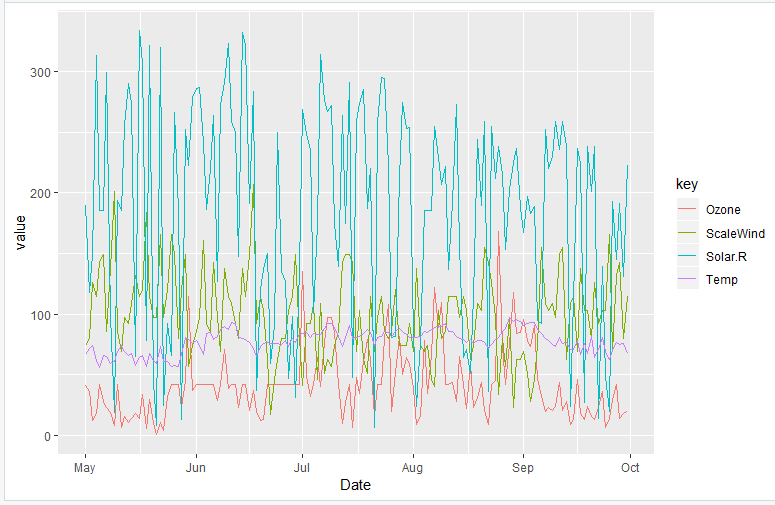

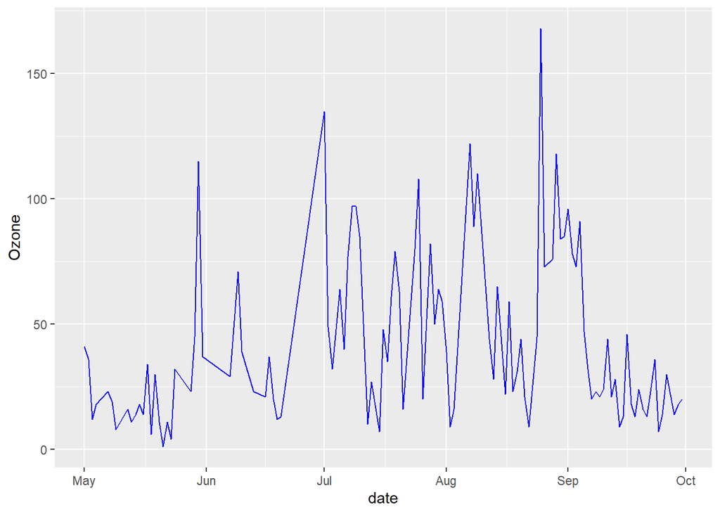

```r
# Write your   below.

rm(linegraph)
airdata$date <- as.Date(paste("1973", airdata$Month,airdata$Day, sep="/"))

ggplot(airdata, aes(x=date, y = Ozone)) + geom_line(color = "blue")
```

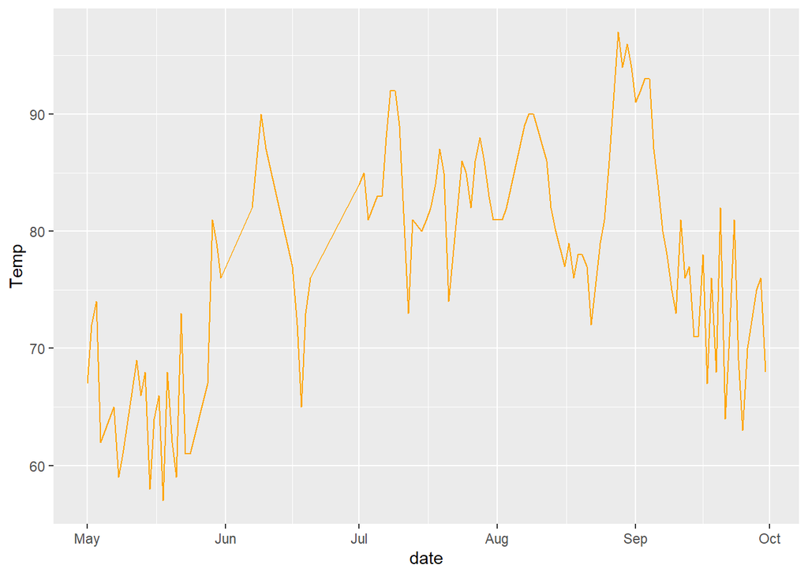

```r
ggplot(airdata, aes(x=date, y = Temp)) + geom_line(color = "Orange")
```

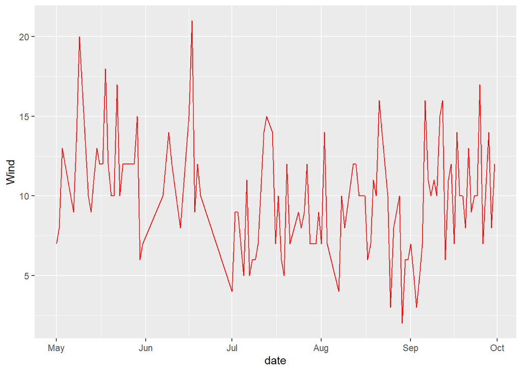

```r
ggplot(airdata, aes(x=date, y = Wind)) + geom_line(color = "Red")
```

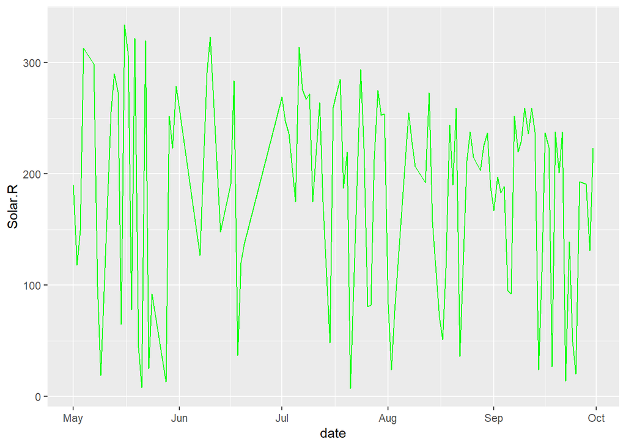

```r
ggplot(airdata, aes(x=date, y = Solar.R)) + geom_line(color = "Green")
```

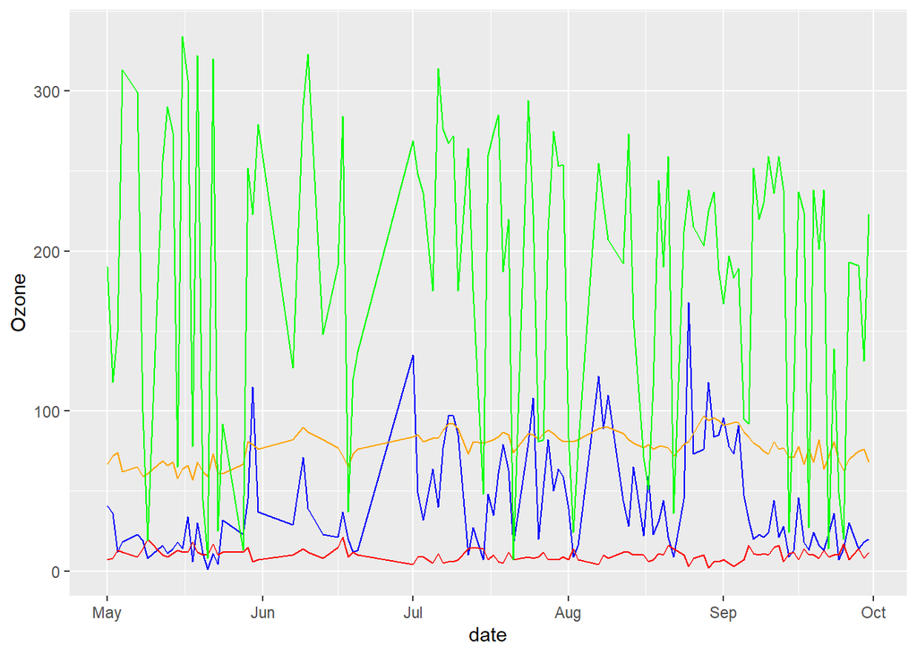

```r
linegraph <- ggplot(airdata, aes(x= date, y = Ozone)) + geom_line(color = "blue")
airdata$Wind = airdata$Wind * 10
linegraph <- linegraph + geom_line(aes(x = date, y = Temp), color = "Orange")
linegraph <- linegraph + geom_line(aes(x = date, y = Wind), color = "red")
linegraph <- linegraph + geom_line(aes(x = date, y = Solar.R), color = "Green")


linegraph
```

# Step 5: Look at all the data via a heatmap

Create a heatmap, with each day (using dates) along the x-axis and `Ozone`, `Temp`, `Wind` and `Solar.r` along the y-axis.

Note that you need to figure out how to show the relative change equally across all the variables.

**HINTS:** - You may find this post helpful: - https://learnr.wordpress.com/2010/01/26/ggplot2-quick-heatmap-plotting/ - Melt the original table to make a long format before visualization using `geom_tile()`

Remember, your programming skills will improve as much as you struggle and put effort in them.

The correct result should look like this:

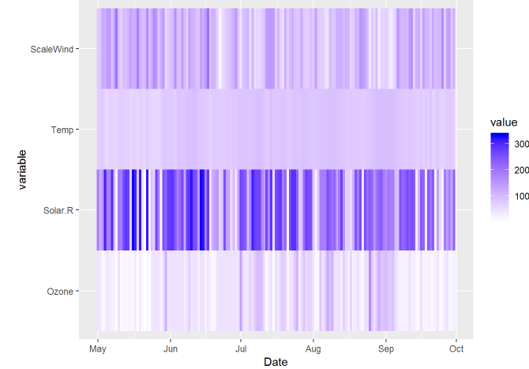

```r
# Write your code below.



air.m <- unite(airdata, Month_Day,Month,Day, sep = "/")
air.melt <- melt(air.m, id=c("Month_Day"))
```

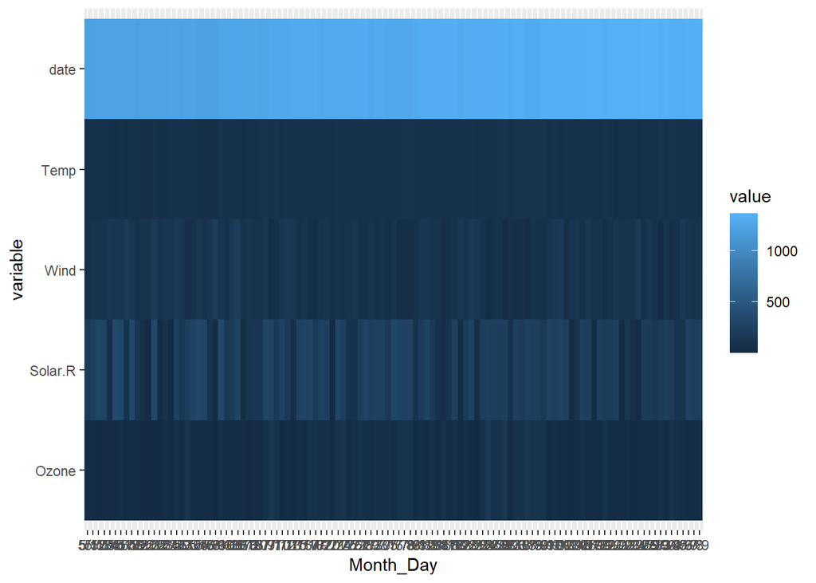

```r
ggplot(air.melt, aes(x=Month_Day, y=variable, fill = value)) + geom_tile()
```

```r
#air.m <- unite(airdata, Month, Day, sep = "/")
```

# Step 6: Look at all the data via a scatter chart

Create a scatter chart, with: - the x-axis representing the `Wind` - the y-axis representing the `Temp` - the size of each dot representing the `Ozone` - the color representing `Solar.R`

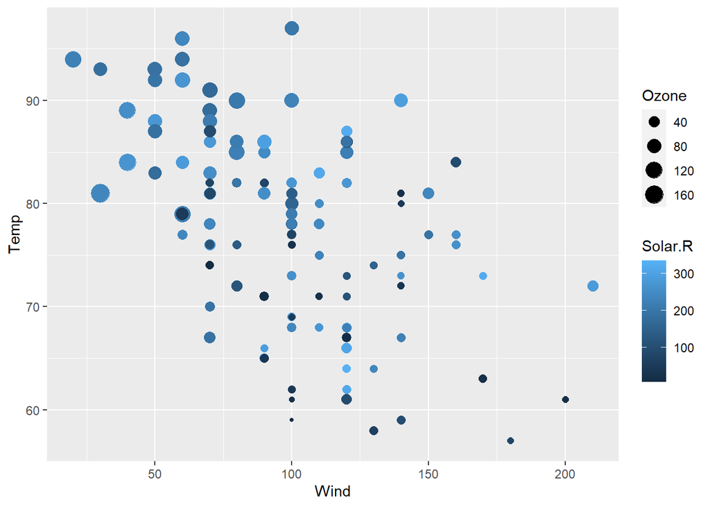

```r
# Write your code below.


ggplot (airdata, aes (Wind, Temp)) +
  geom_point ( aes ( size = Ozone, color = Solar.R))
```

# Step 7: Final analysis

### You MUST answer to these questions in your compiled file.

Do you see any patterns after exploring the data?

> After doing the assignment I have trouble really understanding or “seeing” a pattern. What I did notice is that a lot of the data has to be code and moved aorund in order to properly display results. It seems like it could get into a sticky situation if/when a novice coder begins to mess with the data and visualization.

What was the most useful visualization?

> I believe the Line graphs were the most useful visualization. It let us see how it all moves in a familiar fashion.